# Combining predictors

Jeffrey Leek, Assistant Professor of Biostatistics

## Key ideas

- You can combine classifiers by averaging/voting
  - e.g. You can combine a boosting classifier with a random forest and a linear regression model.
- Combining classifiers improves accuracy
- Combining classifiers reduces interpretability
- Boosting, bagging, and random forests are variants on this theme in which the same type of model is being averaged over varying parameters.

## Netflix prize

BellKor = Combination of 107 predictors

[figure not shown]

http://www.netflixprize.com//leaderboard

## Heritage health prize - Progress Prize 1

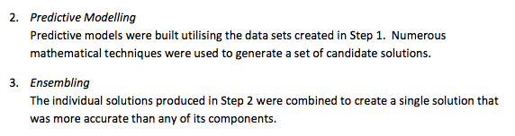

[Market Makers](https://kaggle2.blob.core.windows.net/wiki-files/327/e4cd1d25-eca9-49ca-9593-b254a773fe03/Market%20Makers%20-%20Milestone%201%20Description%20V2%201.pdf)

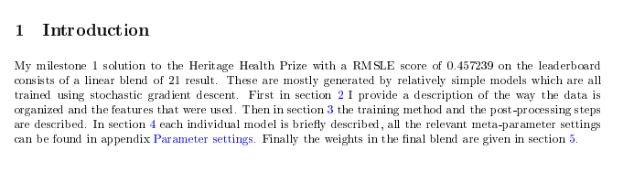

[Mestrom](https://kaggle2.blob.core.windows.net/wiki-files/327/09ccf652-8c1c-4a3d-b979-ce2369c985e4/Willem%20Mestrom%20-%20Milestone%201%20Description%20V2%202.pdf)

## Basic intuition - majority vote

Suppose we have 5 completely independent classifiers

With 101 independent classifiers * 99.9% majority vote accuracy

## Approaches for combining classifiers

1. Bagging, boosting, random forests
- Usually combine similar classifiers
2. Combining different classifiers
- Model stacking
- Model ensembling

## Example with Wage data

**Create training, test and validation sets**

```r
library(ISLR); data(Wage); library(ggplot2); library(caret);
Wage <- subset(Wage,select=-c(logwage))

# Create a building data set and validation set
inBuild <- createDataPartition(y=Wage$wage,
                              p=0.7, list=FALSE)
validation <- Wage[-inBuild,]; buildData <- Wage[inBuild,]

inTrain <- createDataPartition(y=buildData$wage,
                              p=0.7, list=FALSE)
training <- buildData[inTrain,]; testing <- buildData[-inTrain,]
```

## Wage data sets

**Create training, test and validation sets**

```r
dim(training)
```

```
[1] 1474   11
```

```r
dim(testing)
```

```
[1] 628  11
```

```r
dim(validation)
```

```
[1] 898  11
```

## Build two different models

```r
mod1 <- train(wage ~.,method="glm",data=training)
mod2 <- train(wage ~.,method="rf",
              data=training,
              trControl = trainControl(method="cv"),number=3)
```

## Predict on the testing set

Here we plot the predictions of the two models, and colored by ‘wage’.

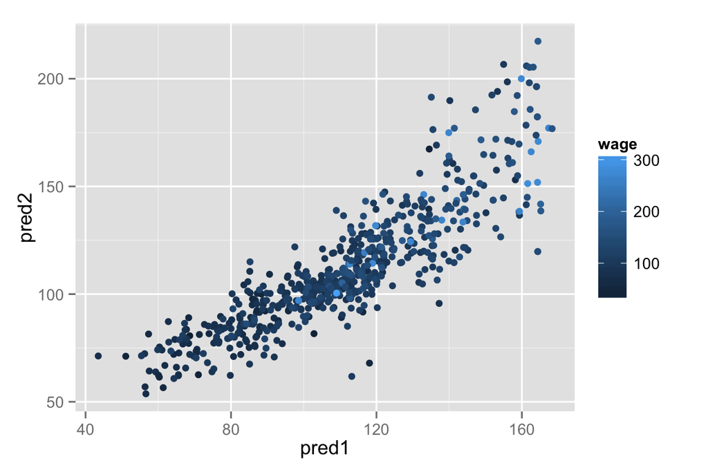

```r
pred1 <- predict(mod1,testing); pred2 <- predict(mod2,testing)
qplot(pred1,pred2,colour=wage,data=testing)
```

## Fit a model that combines predictors

Now we’ll fit a new model that combines those two.

1. Build a new data set from the predictions of both models, as well as the ‘wage’ variable taken from the test set.
2. Fit a regression model from the test ‘wage’ variable and the prediction outcomes as predictors.
3. Make a prediction from the combined data set.

```r
predDF <- data.frame(pred1,pred2,wage=testing$wage)
combModFit <- train(wage ~.,method="gam",data=predDF)
combPred <- predict(combModFit,predDF)
```

## Testing errors

```r
sqrt(sum((pred1-testing$wage)^2))
```

```
[1] 869.1
```

```r
sqrt(sum((pred2-testing$wage)^2))
```

```
[1] 916.7
```

```r
sqrt(sum((combPred-testing$wage)^2))
```

```
[1] 848.3
```

Here we see the errors for each model and the combined model. The combined model has the lowest error.

## Predict on validation data set

We used the test set to blend the two models together. Because we fit the model on the set set, our error is not a good representation of the out-of-sample error. We’ll try the model out on the validation set.

1. We’ll create a prediction of the first model on the validation set. And another prediction of the second model on the validation set.
2. Then create a data frame that contains those predictions.
3. And then we’ll create a third prediction from the combined model on predictions of the validation set (the data frame from the two prediction that we just made).

So the covariates being passed to the model are the predictions from the two different models.

```r
pred1V <- predict(mod1,validation); pred2V <- predict(mod2,validation)
predVDF <- data.frame(pred1=pred1V,pred2=pred2V)
combPredV <- predict(combModFit,predVDF)
```

## Evaluate on validation

```r
sqrt(sum((pred1V-validation$wage)^2))
```

```
[1] 1053
```

```r
sqrt(sum((pred2V-validation$wage)^2))
```

```
[1] 1069
```

```r
sqrt(sum((combPredV-validation$wage)^2))
```

```
[1] 1033
```

Here we see that the error of the combined model is indeed still lower even on the validation set.

## Notes and further resources

- Even simple blending can be useful
- Typical model for binary/multiclass data
- Build an odd number of models
- Predict with each model
- Predict the class by majority vote
- This can get dramatically more complicated
- Simple blending in caret: caretEnsemble (use at your own risk!)
- Wikipedia [ensemlbe learning](http://en.wikipedia.org/wiki/Ensemble_learning)

## Recall - scalability matters

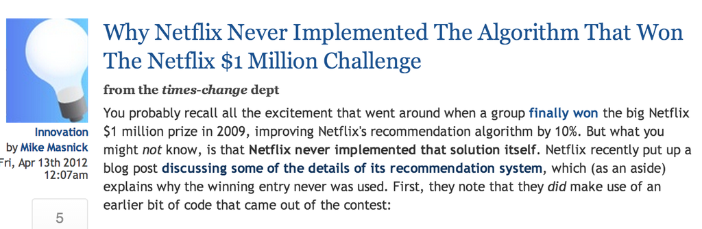

http://www.techdirt.com/blog/innovation/articles/20120409/03412518422/

http://techblog.netflix.com/2012/04/netflix-recommendations-beyond-5-stars.html